# Parallel Computing

Weiquan Luo

2022-08-11

# Theory

## Thread vs Process

- A process consists of multiple thread.
- Threads are sub-units of a process.
- Sharing data is difficult between process, but easy between thread under a same process.
- Same number of processes consume more resource than threads.
- Processes do not affect each other, but failure of one thread would crash the entire process
- Same process can easily expand to multiple computer, but same thread is suitable for expanding on multiple core.
- process can lock the memory adress when the other threads have to be pending until one of its thread use the sharing memory.
- the memory usage of a process can be limited with setup

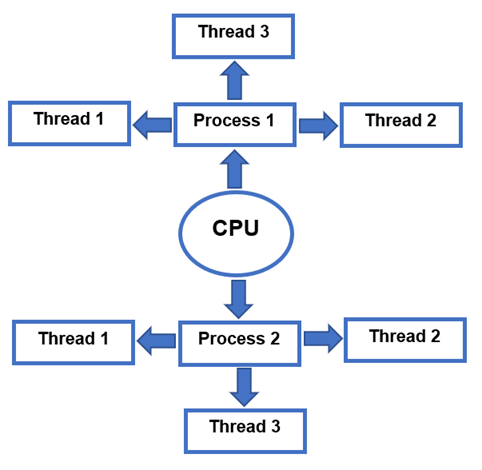

## Parallelism paradigm

Parallelism has many different paradigm, including:

- **Single program, multiple data (SPMD) parallelism**
- Multiple program, multiple data (MPMD) parallelism
- Message passing using MPI
- Task farming
- Data parallel
- Combinations of these approaches
- Custom user-defined approaches

## Load balancing

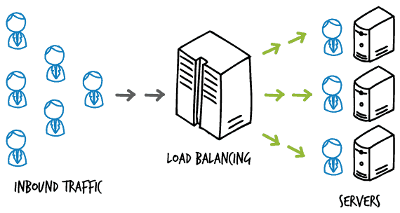

## Pool

When we start 50 processes and let them all reduce the number of 100 to 50, you will find that it is very slow! Issues of efficiency:

- Open up memory space: Data between processes is completely isolated. while a process is opened, a memory space belonging to the process pool will be opened.
- Generate essential for running the process in the independent memory spaces: registers, stacks, files, etc., which store variables and data in this process.
- System scheduling: When switch from process A to B in a CPU. A node between A and B record the execution of the a process up to this point, but also call all the essential of process B before the current execution. This node involves not only the switching of the cpu, but also the data contained in the registers, stacks, etc., as well as the switching of the memory space.

Instead of start the process endlessly, design a process pool to reuse the process to improve the **efficiency** by saving the time for developing processes and memory space and the time for destroying processes.

- pre-defining the number of process in the process pool,
- fill up these processes with scheduler
- when one task is completed in a process, this process won't close and another tasks come in.

## synchronous vs asynchronous

| type | definition | Application | function |
| --- | --- | --- | --- |
| synchronous | execute a task after the previous task is completed | - safe for tasks with dependencies, but maybe long wait time | `ipyparallel.map_sync()` |
| asynchronous | execute a task regardless the status of previous task | - unsafe for tasks with dependencies - fast for independent task. | `ipyparallel.map_async()` |

## pickle

- **pickle** in Python is primarily used in serializing and deserializing a Python object structure. In other words, it's the process of converting a *Python object* into a *byte stream* (.pickle) to:
  - store it in a file/database,
  - maintain program state across sessions,
  - transport data over the network/**process** (.pickle is similar to .JSON，YAML，XML)
  - [What can be pickled and unpickled?](https://docs.python.org/2/library/pickle.html#what-can-be-pickled-and-unpickled)

## Global Interpreter Lock

Python's multithreading cannot take advantage of multiple cores of a cpu:

- The official interpreter of python is Cython, which uses the **GIL (Global Interpreter Lock)** lock when executing code.
- This lock is acquired before any thread executes. The lock is global and only one, so a lock cannot be owned by two threads at the same time. The interpreter periodically releases the lock, and multiple threads use the lock in time-sharing. Therefore, only one thread holds the lock at a time ([为什么Python多线程无法利用多核](https://blog.51cto.com/u_15303040/3109644)). The GIL was applied to improves the computation efficiency in the era of CPU with single logical core, but it limites python to utilize the power of CPU with multicore nowadays.
- Effect: GIL might not affect I/O-heavy tasks, but badly limite the computation-heavy tasks.
- Simple solution: Each core has only one activating thread at each moment. Each logical core/process own a GIL, and only one thread is distributed on each logical core.

## package comparison

[output not shown]

## Best practice

Trading off on computational complexity between time and memory:

- Synchronously paralleling tasks on multiple **threads** under a same process reduces resource-consuming:
  - when tasks are dependent
  - when tasks sharing large data or many objects
- Asynchronously paralleling tasks on multiple **processes** reduces computational time:
  - when tasks are independent
  - when tasks are computationally heavy

# Example function

```python
import os, time
import numpy as np
from random import sample
```

## HelloWorld( )

```python
# define function
def HelloWorld(x = None):
    if x is not None:
        return 'Hello '+ str(x)
    else:
        return 'Hello World'
```

```python
%%time
res = HelloWorld()
```

```
CPU times: user 4 µs, sys: 14 µs, total: 18 µs
Wall time: 7.15 µs
```

```python
%%time
for i in np.arange(0,5):
    res = HelloWorld(i)
```

```
CPU times: user 181 µs, sys: 80 µs, total: 261 µs
Wall time: 34.8 µs
```

## RandomForestClassifier( )

```python
# make dataset
from sklearn.datasets import make_classification
X, y = make_classification(n_samples=10000, n_features=10,
                           n_informative=10, n_redundant=0,
                           random_state=0, shuffle=False)
# define function
from sklearn.ensemble import RandomForestClassifier
def clf_fit_predict(i, X, y):
    clf = RandomForestClassifier(max_depth=10, random_state=0)
    clf = clf.fit(X, y)
    return i, clf.predict(X)
```

```python
%%time
res = clf_fit_predict(0, X, y)
# %%timeit 1.68 s ± 12.7 ms per loop (mean ± std. dev. of 7 runs, 1 loop each)
```

```
CPU times: user 1.45 s, sys: 7.09 ms, total: 1.46 s
Wall time: 1.46 s
```

```python
%%time
for i in np.arange(0, 15):
    res = clf_fit_predict(0, X, y)
# %%timeit 29.5 s ± 548 ms per loop (mean ± std. dev. of 7 runs, 1 loop each)
```

```
CPU times: user 21.5 s, sys: 69.5 ms, total: 21.6 s
Wall time: 21.6 s
```

# ipyparallel

- [ipyparallel 8.4.1: Using IPython for parallel computing](https://ipyparallel.readthedocs.io/en/latest/)
- [ipyparallel 8.4.1: Tutorial](https://ipyparallel.readthedocs.io/en/latest/tutorial/index.html)

```
# installation
pip install notebook ipyparallel
ipcluster nbextension enable
ipython profile create --parallel --profile=myprofile
```

```python
import ipyparallel as ipp
```

```python
# setup for cluster profile
cluster = ipp.Cluster(n=5)
# starting engine by connecting a client with showing progress bar
rc = cluster.start_and_connect_sync()
# open controller
view = rc.direct_view()
# submit task to cluster and execute
result = view.apply_async(os.getpid)
# wait function execution with showing progress bar
result.wait_interactive()
# collect result
result = result.get_dict()
rc.shutdown(hub=True)
print(f'\n result: {result} \n')
```

```
Using existing profile dir: '/Users/weiquanluo/.ipython/profile_default'
Starting 5 engines with <class 'ipyparallel.cluster.launcher.LocalEngineSetLauncher'>
```

```
 result: {0: 30853, 1: 30854, 2: 30855, 3: 30856, 4: 30857}
```

## architecture

The IPython architecture consists of four components:

- Engine: an extension of the IPython kernel for Jupyter.
  - listens for requests over the network,
  - runs code, and
  - returns results
- Hub: The center of an IPython cluster that keeps track of engine connections, schedulers, clients, as well as all task requests and results. The primary role of the Hub is to
  - facilitate queries of the cluster state, and
  - minimize the necessary information required to establish the many connections involved in connecting new clients and engines.
- Schedulers: the processes provide a fully asynchronous function to a set of engines
- Client: the `Client` class for connecting to a cluster.
  - allow users to interact with a set of engines through the ipyparallel interface.

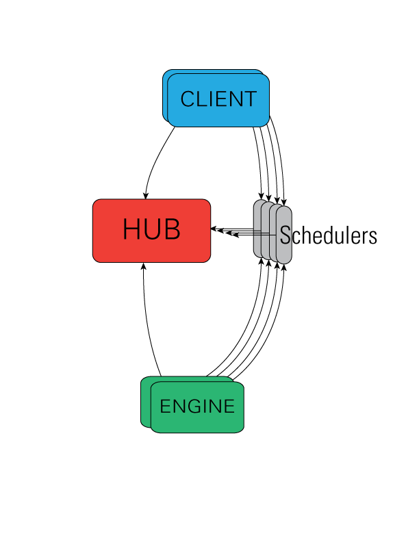

## Context manager

The Parallel processing in ipyparallel will walk throught the following steps:

- Entering a Cluster context
  - starts the cluster
  - waits for engines to be ready
  - connects a client
  - returns the client
- Exiting a Client context closes the client’s socket connections to the cluster.
- Exiting a Cluster context shuts down all of the cluster’s resources.

The use of context managers is encouraged if the cluster is not longer needed after use. In ipyparallel, the `Cluster` and `Client` classes can be used as context managers. The context managers help to:

- connect and disconnect clients
- interacting with engines
- easier cleanup of resources

```python
# Cluster as Context manager
with ipp.Cluster(n=5) as rc: # setup for cluster profile, starting engine by connecting a client with showing progress bar
    # open controller
    dview = rc.direct_view()
    # submit task to cluster and execute
    result = dview.apply_async(os.getpid)
    # wait function execution with showing progress bar
    result.wait_interactive()
    # collect result
    result = result.get_dict()
# at this point, the cluster processes have been shutdown
time.sleep(0.5)
print(f'\n result: {result} \n')
```

[output not shown]

```
Stopping engine(s): 1660251586
engine set stopped 1660251586: {'engines': {'0': {'exit_code': 0, 'pid': 30897, 'identifier': '0'}, '1': {'exit_code': 0, 'pid': 30898, 'identifier': '1'}, '2': {'exit_code': 0, 'pid': 30899, 'identifier': '2'}, '3': {'exit_code': 0, 'pid': 30900, 'identifier': '3'}, '4': {'exit_code': 0, 'pid': 309…
Stopping controller
Controller stopped: {'exit_code': 0, 'pid': 30885, 'identifier': 'ipcontroller-1660251585-rob1-30830'}

 result: {0: 30897, 1: 30898, 2: 30899, 3: 30900, 4: 30901}
```

## Controller

Controller: a collection of processes that provides an **interface** . The two primary models for interacting with engines are:

| Controller model | Definition | Use case |
| --- | --- | --- |
| `DirectView` class | Engines are addressed explicitly | 1) import package 2) upload function 3) The number of tasks and engines are equal. |
| `LoadBalancedView` class | Scheduler is entrusted with assigning work to appropriate engines in a destination-agnostic manner. | 1) run function 2) The number of tasks is more than the number of engines |

### Drect view

- `ipp.Client().direct_view()`: A Direct interface, where engines are addressed explicitly
  - `dview = rc[:]`: use all engines

```python
with ipp.Cluster(n=5) as rc:
    # upload funtion
    dview = rc.direct_view()
    dview.push({'HelloWorld': HelloWorld})
    result = dview.apply_async(HelloWorld)
    result.wait_interactive()
    result = result.get()
time.sleep(0.5)
print(f'\n result: {result} \n')
```

```
Using existing profile dir: '/Users/weiquanluo/.ipython/profile_default'
Starting 5 engines with <class 'ipyparallel.cluster.launcher.LocalEngineSetLauncher'>
```

```
Stopping engine(s): 1660251595
engine set stopped 1660251595: {'engines': {'0': {'exit_code': 0, 'pid': 30940, 'identifier': '0'}, '1': {'exit_code': 0, 'pid': 30941, 'identifier': '1'}, '2': {'exit_code': 0, 'pid': 30942, 'identifier': '2'}, '3': {'exit_code': 0, 'pid': 30943, 'identifier': '3'}, '4': {'exit_code': 0, 'pid': 309…
Stopping controller
Controller stopped: {'exit_code': 0, 'pid': 30928, 'identifier': 'ipcontroller-1660251594-auc2-30830'}

 result: ['Hello World', 'Hello World', 'Hello World', 'Hello World', 'Hello World']
```

### Load balanced view

- `load_balanced_view()`: A LoadBalanced interface, where the Scheduler is entrusted with assigning work to appropriate engines

```python
with ipp.Cluster(n=5) as rc:
    # upload funtion
    dview = rc.direct_view()
    dview.push({'HelloWorld': HelloWorld})
    lview = rc.load_balanced_view()
    result = lview.map_async(HelloWorld, np.arange(0,10))
    result.wait_interactive()
    result = result.get()
time.sleep(0.5)
print(f'\n result: {result} \n')
```

```
Using existing profile dir: '/Users/weiquanluo/.ipython/profile_default'
Starting 5 engines with <class 'ipyparallel.cluster.launcher.LocalEngineSetLauncher'>
```

```
Stopping engine(s): 1660251604
engine set stopped 1660251604: {'engines': {'0': {'exit_code': 0, 'pid': 30983, 'identifier': '0'}, '1': {'exit_code': 0, 'pid': 30984, 'identifier': '1'}, '2': {'exit_code': 0, 'pid': 30985, 'identifier': '2'}, '3': {'exit_code': 0, 'pid': 30986, 'identifier': '3'}, '4': {'exit_code': 0, 'pid': 309…
Stopping controller
Controller stopped: {'exit_code': 0, 'pid': 30971, 'identifier': 'ipcontroller-1660251603-x4xj-30830'}

 result: ['Hello 0', 'Hello 1', 'Hello 2', 'Hello 3', 'Hello 4', 'Hello 5', 'Hello 6', 'Hello 7', 'Hello 8', 'Hello 9']
```

## Interface: `View` class

- `DirectView.execute()`: import package with string
- `DirectView.push()`: upload function with dict
- `View.apply()`
- `View.apply_async()`
- `View.apply_sync()`
- `View.map_async()`
- `View.map_sync()`

## Example

### single argument

```python
with ipp.Cluster(n=5) as rc:
    dview = rc.direct_view()
    result1 = dview.apply_async(HelloWorld) # each engines run function without input arguments
    result2 = dview.apply_async(HelloWorld, np.arange(0,10)) # each engines run function with the entire object
    result3 = dview.map_async(HelloWorld, np.arange(0,10)) # the object are slided into single element and feed into the function
    result1.wait_interactive()
    result2.wait_interactive()
    result3.wait_interactive()
    result1 = result1.get()
    result2 = result2.get()
    result3 = result3.get()
time.sleep(0.5)
print(f'\n result1: {result1} \n')
print(f'\n result2: {result2} \n')
print(f'\n result3: {result3} \n')
```

```
Using existing profile dir: '/Users/weiquanluo/.ipython/profile_default'
Starting 5 engines with <class 'ipyparallel.cluster.launcher.LocalEngineSetLauncher'>
```

```
Stopping engine(s): 1660251612
engine set stopped 1660251612: {'engines': {'0': {'exit_code': 0, 'pid': 31027, 'identifier': '0'}, '1': {'exit_code': 0, 'pid': 31028, 'identifier': '1'}, '2': {'exit_code': 0, 'pid': 31029, 'identifier': '2'}, '3': {'exit_code': 0, 'pid': 31030, 'identifier': '3'}, '4': {'exit_code': 0, 'pid': 310…
Stopping controller
Controller stopped: {'exit_code': 0, 'pid': 31015, 'identifier': 'ipcontroller-1660251611-dopl-30830'}

 result1: ['Hello World', 'Hello World', 'Hello World', 'Hello World', 'Hello World']


 result2: ['Hello [0 1 2 3 4 5 6 7 8 9]', 'Hello [0 1 2 3 4 5 6 7 8 9]', 'Hello [0 1 2 3 4 5 6 7 8 9]', 'Hello [0 1 2 3 4 5 6 7 8 9]', 'Hello [0 1 2 3 4 5 6 7 8 9]']


 result3: ['Hello 0', 'Hello 1', 'Hello 2', 'Hello 3', 'Hello 4', 'Hello 5', 'Hello 6', 'Hello 7', 'Hello 8', 'Hello 9']
```

### multiple argument

```python
%%time
with ipp.Cluster(n=15) as rc:
    dview = rc.direct_view()
    # upload package
    dview.execute("from sklearn.datasets import make_classification")
    dview.execute("from sklearn.ensemble import RandomForestClassifier")
    # upload function
    dview.push({'clf_fit_predict': clf_fit_predict})
    time.sleep(1) # give some time to upload
    # submit task and execute
    result = dview.apply_async(clf_fit_predict, i = 0, X = X, y = y)
    result.wait_interactive()
    result = result.get()
time.sleep(0.5)
print(f'\n result: {result} \n')
# %%timeit 14.6 s ± 250 ms per loop (mean ± std. dev. of 7 runs, 1 loop each)
```

```
Using existing profile dir: '/Users/weiquanluo/.ipython/profile_default'
Starting 15 engines with <class 'ipyparallel.cluster.launcher.LocalEngineSetLauncher'>
```

```
Stopping engine(s): 1660251621
engine set stopped 1660251621: {'engines': {'0': {'exit_code': 0, 'pid': 31070, 'identifier': '0'}, '1': {'exit_code': 0, 'pid': 31071, 'identifier': '1'}, '2': {'exit_code': 0, 'pid': 31072, 'identifier': '2'}, '3': {'exit_code': 0, 'pid': 31073, 'identifier': '3'}, '4': {'exit_code': 0, 'pid': 310…
Stopping controller
Controller stopped: {'exit_code': 0, 'pid': 31057, 'identifier': 'ipcontroller-1660251620-t49m-30830'}

 result: [(0, array([0, 0, 0, ..., 1, 1, 1])), (0, array([0, 0, 0, ..., 1, 1, 1])), (0, array([0, 0, 0, ..., 1, 1, 1])), (0, array([0, 0, 0, ..., 1, 1, 1])), (0, array([0, 0, 0, ..., 1, 1, 1])), (0, array([0, 0, 0, ..., 1, 1, 1])), (0, array([0, 0, 0, ..., 1, 1, 1])), (0, array([0, 0, 0, ..., 1, 1, …

CPU times: user 378 ms, sys: 344 ms, total: 722 ms
Wall time: 14.3 s
```

### multiple argument with partial filled

```python
%%time
from functools import partial
my_task = partial(clf_fit_predict, X = X, y = y)
def task(i):
    return my_task(i)
# launch cluster
with ipp.Cluster(n=5) as rc:
    dview = rc.direct_view()
    # import package
    dview.execute("from sklearn.ensemble import RandomForestClassifier")
    # upload function
    dview.push({'clf_fit_predict': clf_fit_predict, # core func
                'my_task': my_task, # core func with partial argument
                'task': task}) # extra warper on core func with partial argument
    time.sleep(1) # give some time to upload
    # submit task and execute
    lview = rc.load_balanced_view()
    result = lview.map_async(task, np.arange(0,15))
    result.wait_interactive()
    result = result.get()
time.sleep(0.5)
print(f'\n result: {result} \n')
```

```
Using existing profile dir: '/Users/weiquanluo/.ipython/profile_default'
Starting 5 engines with <class 'ipyparallel.cluster.launcher.LocalEngineSetLauncher'>
```

```
Stopping engine(s): 1660251635
engine set stopped 1660251635: {'engines': {'0': {'exit_code': 0, 'pid': 31176, 'identifier': '0'}, '1': {'exit_code': 0, 'pid': 31177, 'identifier': '1'}, '2': {'exit_code': 0, 'pid': 31178, 'identifier': '2'}, '3': {'exit_code': 0, 'pid': 31179, 'identifier': '3'}, '4': {'exit_code': 0, 'pid': 311…
Stopping controller
Controller stopped: {'exit_code': 0, 'pid': 31164, 'identifier': 'ipcontroller-1660251634-dgf5-30830'}

 result: [(0, array([0, 0, 0, ..., 1, 1, 1])), (1, array([0, 0, 0, ..., 1, 1, 1])), (2, array([0, 0, 0, ..., 1, 1, 1])), (3, array([0, 0, 0, ..., 1, 1, 1])), (4, array([0, 0, 0, ..., 1, 1, 1])), (5, array([0, 0, 0, ..., 1, 1, 1])), (6, array([0, 0, 0, ..., 1, 1, 1])), (7, array([0, 0, 0, ..., 1, 1, …

CPU times: user 225 ms, sys: 128 ms, total: 354 ms
Wall time: 14.5 s
```

# Reference

- [Python中的并行运算](https://zhuanlan.zhihu.com/p/26222131)
- [multiprocessing多进程实例](https://blog.csdn.net/ztf312/article/details/77851607)
- [python 进程池pool简单实例](https://cloud.tencent.com/developer/article/1564227)
- [Python 基本功: 14. 多核并行计算](https://zhuanlan.zhihu.com/p/93305921)
- [GPU 加速计算](https://qa.1r1g.com/sf/ask/3935418231/)
- [【效率提升】Python中的并行运算](https://zhuanlan.zhihu.com/p/26222131)
- [Python MultiProcessing 使用心得](http://luly.lamost.org/blog/python_multiprocessing.html)
- [multiprocessing： 用进程池Pool进行代码加速](https://zhpmatrix.github.io/2017/11/04/speed-up-python/)
- [Cannot pass argument to method using multiprocessing.Pool](https://stackoverflow.com/questions/46230599/cannot-pass-argument-to-method-using-multiprocessing-pool)

```python
!python3 -m jupyter nbconvert jupyter_ParallelComputing.ipynb --to html
```

```
[NbConvertApp] Converting notebook jupyter_ParallelComputing.ipynb to html
[NbConvertApp] Writing 648039 bytes to jupyter_ParallelComputing.html
```